# Practical Machine Learning Project

Freddy Li

July 13, 2019

#### Overview

Using devices such as Jawbone Up, Nike FuelBand, and Fitbit it is now possible to collect a large amount of data about personal activity relatively inexpensively. These type of devices are part of the quantified self movement – a group of enthusiasts who take measurements about themselves regularly to improve their health, to find patterns in their behavior, or because they are tech geeks. One thing that people regularly do is quantify how much of a particular activity they do, but they rarely quantify how well they do it. In this project, our goal is to use data from accelerometers on the belt, forearm, arm, and dumbell of 6 participants. They were asked to perform barbell lifts correctly and incorrectly in 5 different ways. The data consists of a Training set,{r}[train](https://d396qusza40orc.cloudfront.net/predmachlearn/pml-training.csv), for model building and a Testing set, {r}[test](https://d396qusza40orc.cloudfront.net/predmachlearn/pml-testing.csv), for prediction based on the built model. * More information is available from the website here: {r}[reference link](http://groupware.les.inf.puc-rio.br/har)

#### Data Loading and Cleaning

## Environment Preparation

Firstly, we load the R libraries and set seed that are necessary for the complete analysis.

```r
library(caret)
library(knitr)
library(rattle)
set.seed(10)
```

## Data Loading

Next, we load the data from 2 url for training and testing sets.

```r
url_Train <- "https://d396qusza40orc.cloudfront.net/predmachlearn/pml-training.csv"
url_Test <- "https://d396qusza40orc.cloudfront.net/predmachlearn/pml-testing.csv"

if(!file.exists("Train.csv")) {download.file(url_Train, "Train.csv")}
if(!file.exists("Test.csv")) {download.file(url_Test, "Test.csv")}

Train <- read.csv("Train.csv")
Test <- read.csv("Test.csv")
```

## Data Exploratory Analysis

Then, we observe the data structure and content based on training set.

```r
dim(Train);dim(Test)
```

```
## [1] 19622   160
```

```
## [1]  20 160
```

```r
str(Train)
```

```
## 'data.frame':    19622 obs. of  160 variables:
##  $ X                       : int  1 2 3 4 5 6 7 8 9 10 ...
##  $ user_name               : Factor w/ 6 levels "adelmo","carlitos",..: 2 2 2 2 2 2 2 2 2 2 ...
##  $ raw_timestamp_part_1    : int  1323084231 1323084231 1323084231 1323084232 1323084232 1323084232 1323084232 1323084232 1323084232 1323084232 ...
##  $ raw_timestamp_part_2    : int  788290 808298 820366 120339 196328 304277 368296 440390 484323 484434 ...
##  $ cvtd_timestamp          : Factor w/ 20 levels "02/12/2011 13:32",..: 9 9 9 9 9 9 9 9 9 9 ...
##  $ new_window              : Factor w/ 2 levels "no","yes": 1 1 1 1 1 1 1 1 1 1 ...
##  $ num_window              : int  11 11 11 12 12 12 12 12 12 12 ...
##  $ roll_belt               : num  1.41 1.41 1.42 1.48 1.48 1.45 1.42 1.42 1.43 1.45 ...
##  $ pitch_belt              : num  8.07 8.07 8.07 8.05 8.07 8.06 8.09 8.13 8.16 8.17 ...
##  $ yaw_belt                : num  -94.4 -94.4 -94.4 -94.4 -94.4 -94.4 -94.4 -94.4 -94.4 -94.4 ...
##  $ total_accel_belt        : int  3 3 3 3 3 3 3 3 3 3 ...
##  $ kurtosis_roll_belt      : Factor w/ 397 levels "","-0.016850",..: 1 1 1 1 1 1 1 1 1 1 ...
##  $ kurtosis_picth_belt     : Factor w/ 317 levels "","-0.021887",..: 1 1 1 1 1 1 1 1 1 1 ...
##  $ kurtosis_yaw_belt       : Factor w/ 2 levels "","#DIV/0!": 1 1 1 1 1 1 1 1 1 1 ...
```

[output cut: 86 more lines]

Based on the observations, we find there are 160 variables totally including identication information, related collected data and some variables including plenty of NA.

## Data Cleaning

To avoid noises from the data, we remove the variables without variance mostly, variables including plenty of NA and variables about identification information.

```r
# Remove the variables with nearly zero variance
NZV <- nearZeroVar(Train)
Train <- Train[,-NZV]
Test <- Test[,-NZV]
dim(Train);dim(Test)
```

```
## [1] 19622   100
```

```
## [1]  20 100
```

```r
# Remove the variables which are basically NA
ISNA <- sapply(Train, function(x) mean(is.na(x)))>0.95 #95%
Train <- Train[,ISNA==FALSE]
Test <- Test[,-ISNA==FALSE]
dim(Train);dim(Test)
```

```
## [1] 19622    59
```

```
## [1] 20 59
```

```r
# Remove the identification variables including index, names and timestamp (the first 5 columns)
Train1 <- Train[,-(1:5)]
Test1 <-Test[,-(1:5)]
dim(Train1);dim(Test1)
```

```
## [1] 19622    54
```

```
## [1] 20 54
```

Through the cleaning process, we remove 60 variables without variance basically, 41 variables with NA over 95% and 5 variables for identification information.Finally, we have 54 variables to fit models including the outcome variable, classes.

#### Prediction Model Building

To build model, we analyze the training data completely so initially we divide the training data into 2 subsets including a sub training set (70%) for model training and a sub testing model (30%) for validation.Then, we use 3 different algothms including classification trees, gradient boosting model and random forests to fit models and judge which model is the best one according to accuracy ratio. For all fitting models, we apply cross-validation with k=3.

```r
# Create 2 subsets to validate model when building models.
inTrain <-createDataPartition(y=Train1$classe,p=0.70,list=FALSE) # 70% for Training
TrainSet <-Train1[inTrain,]
TestSet <- Train1[-inTrain,]
```

## Classification Tree

```r
# Classification Tree:
modFit1 <-train(classe~.,data = TrainSet,method="rpart",trControl=trainControl(method = "cv",number=3))
print(modFit1$finalModel)
```

```
## n= 13737
##
## node), split, n, loss, yval, (yprob)
##       * denotes terminal node
##
##  1) root 13737 9831 A (0.28 0.19 0.17 0.16 0.18)
##    2) roll_belt< 130.5 12604 8707 A (0.31 0.21 0.19 0.18 0.11)
##      4) pitch_forearm< -33.95 1100    8 A (0.99 0.0073 0 0 0) *
##      5) pitch_forearm>=-33.95 11504 8699 A (0.24 0.23 0.21 0.2 0.12)
##       10) num_window>=45.5 10983 8178 A (0.26 0.24 0.22 0.2 0.09)
##         20) magnet_dumbbell_y< 439.5 9346 6604 A (0.29 0.19 0.25 0.19 0.085)
##           40) num_window< 241.5 2212  895 A (0.6 0.13 0.12 0.12 0.032) *
##           41) num_window>=241.5 7134 5083 C (0.2 0.2 0.29 0.21 0.1)
##             82) magnet_dumbbell_z< -27.5 1586  558 A (0.65 0.22 0.058 0.059 0.016) *
##             83) magnet_dumbbell_z>=-27.5 5548 3589 C (0.072 0.2 0.35 0.25 0.13) *
##         21) magnet_dumbbell_y>=439.5 1637  736 B (0.038 0.55 0.046 0.25 0.12) *
##       11) num_window< 45.5 521  105 E (0 0 0 0.2 0.8) *
##    3) roll_belt>=130.5 1133    9 E (0.0079 0 0 0 0.99) *
```

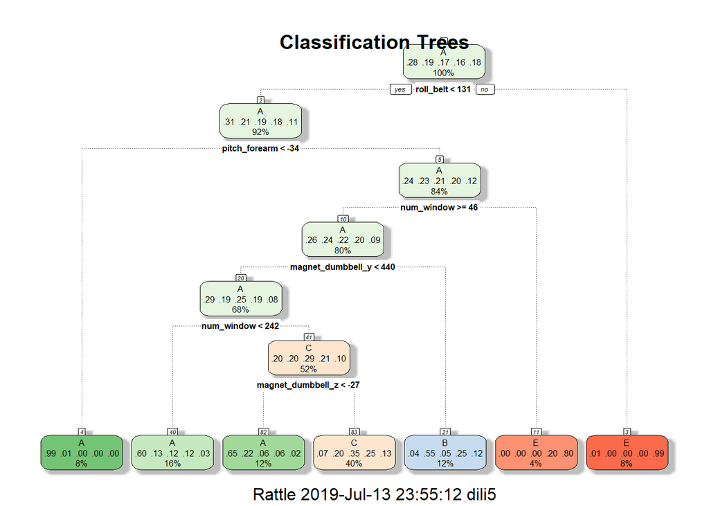

```r
fancyRpartPlot(modFit1$finalModel, main = "Classification Trees")
```

```r
# Prediction and Accuracy Checking
Pred1 <- predict(modFit1,newdata = TestSet)
Check1 <- confusionMatrix(Pred1,TestSet$classe)
Check1$table
```

```
##           Reference
## Prediction    A    B    C    D    E
##          A 1489  291  160  174   40
##          B   18  385   32  165   81
##          C  162  463  834  584  297
##          D    0    0    0    0    0
##          E    5    0    0   41  664
```

```r
Check1$overall[1]
```

```
##  Accuracy
## 0.5729822
```

## GBM (Gradient Boosting Model)

```r
# GBM (gradient boosted model)
modFit2 <-train(classe~.,data = TrainSet,method="gbm",verbose=FALSE, trControl=trainControl(method = "cv",number=3))
print(modFit2$finalModel)
```

```
## A gradient boosted model with multinomial loss function.
## 150 iterations were performed.
## There were 53 predictors of which 53 had non-zero influence.
```

```r
# Prediction and Accuracy Checking
Pred2 <- predict(modFit2,newdata = TestSet)
Check2 <- confusionMatrix(Pred2,TestSet$classe)
Check2$table
```

```
##           Reference
## Prediction    A    B    C    D    E
##          A 1663   17    0    0    1
##          B   10 1101    9    3    2
##          C    0   16 1011    8    1
##          D    1    5    5  951    9
##          E    0    0    1    2 1069
```

```r
Check2$overall[1]
```

```
##  Accuracy
## 0.9847069
```

## Random Forests

```r
# Random Forests
modFit3 <-train(classe~.,data = TrainSet,method="rf",prox=T, trControl=trainControl(method = "cv",number=3))
print(modFit3$finalModel)
```

```
##
## Call:
##  randomForest(x = x, y = y, mtry = param$mtry, proximity = ..1)
##                Type of random forest: classification
##                      Number of trees: 500
## No. of variables tried at each split: 27
##
##         OOB estimate of  error rate: 0.21%
## Confusion matrix:
##      A    B    C    D    E  class.error
## A 3904    1    0    0    1 0.0005120328
## B    5 2648    4    1    0 0.0037622272
## C    0    7 2389    0    0 0.0029215359
## D    0    0    6 2245    1 0.0031083481
## E    0    0    0    3 2522 0.0011881188
```

```r
# Prediction and Accuracy Checking
Pred3 <- predict(modFit3,newdata = TestSet)
Check3 <- confusionMatrix(Pred3,TestSet$classe)
Check3$table
```

```
##           Reference
## Prediction    A    B    C    D    E
##          A 1674    3    0    0    0
##          B    0 1133    3    0    0
##          C    0    2 1023    2    0
##          D    0    1    0  962    1
##          E    0    0    0    0 1081
```

```r
Check3$overall[1]
```

```
##  Accuracy
## 0.9979609
```

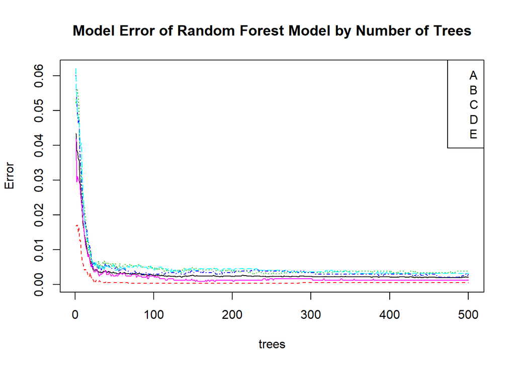

```r
#Plot
plot(modFit3$finalModel, main="Model Error of Random Forest Model by Number of Trees")
legend("topright", legend=unique(TrainSet$classe))
```

#### Application of Best Model for Prediction of 20 Test Sets

The accuracy of 3 models are: * Classification Trees: 0.5729822 * GBM: 0.9847069 * Random Forests: 0.9979609

According, we decide to use Random Forests model to predict the results for testing dataset as following.

```r
pred <- predict(modFit3,newdata = Test1)
pred
```

```
##  [1] B A B A A E D B A A B C B A E E A B B B
## Levels: A B C D E
```